# Roteiro 5 - Regressão linear no software R

Luis Felipe Bortolatto da Cunha

# 1. Introdução

Para executar a análise de correlação vamos utilizar dados demográficos e de consumo de água de 2010, para uma amostra de 4.417 municípios, extraídos do Censo Demográfico (IBGE) e Sistema Nacional de Informações sobre Saneamento (SNIS), para investigar em que medida **o consumo de água está relacionado com a renda**, conforme análise apresentada por [Carmo et al., 2013](https://abrh.s3.sa-east-1.amazonaws.com/Sumarios/155/ea6a64ffc76c211d6b7749ab8444b626_bf87b0b219dd784ffa049f367598e626.pdf).

### 1.1. Instalação e importação de pacotes

O software estatístico R já conta com funções básicas que permitem executar uma análise de regressão linear. Mas além das funções básicas, vamos usar os pacotes:

- `readr`: para importar a base de dados em formato `csv2`
- `dplyr`: para adicionar o operador `%>%` e a função `mutate()`

Se você ainda não possui esses pacotes instalados, é necessário executar o comando abaixo para instalar.

```r
install.packages("readr")
install.packages("dplyr")
```

Após a instalação, você pode importá-los com o uso da função `library()`.

```r
library(readr)
library(dplyr)
```

### 1.2. Importação da base de dados

Uma base de dados pré-processada está disponível no endereço abaixo: https://raw.githubusercontent.com/luisfelipebr/mti/master/dados/Agua2010_IBGE_SNIS.csv

Para importá-la é necessário usar a função `read_csv2()`.

```r
dados <- read_csv2("https://raw.githubusercontent.com/luisfelipebr/mti/master/dados/Agua2010_IBGE_SNIS.csv")
```

### 1.3. Análise exploratória

A função `names()` exibe os nomes das variáveis.

```r
names(dados)
```

```
##  [1] "ID_IBGE"   "ID_SNIS"   "MUNICIP1"  "MUNICIP2"  "UF"        "REGIAO"
##  [7] "CENTRX"    "CENTRY"    "RENDAPITA" "GINI"      "PIB"       "IDH"
## [13] "AG001"     "AG020"     "AG022"     "GE012"     "CONSUMO1"  "CONSUMO2"
## [19] "REDE"      "PROPREDE"
```

Como é possível ver após a execução do comando, os nomes das variáveis estão codificados. Mas a tabela abaixo apresenta uma descrição de cada variável.

| Código | Descrição |
| --- | --- |
| ID_IBGE | ID do IBGE |
| ID_SNIS | ID do SNIS |
| MUNICIP1 | Nome do Municipio 1 |
| MUNICIP2 | Nome do Municipio 2 |
| UF | UF |
| REGIAO | Regiao do pais |
| CENTRX | Centroide (X) |
| CENTRY | Centroide (Y) |
| RENDAPITA | Renda per Capita 2010 |
| GINI | Indice Gini 2010 |
| PIB | PIB 2010 |
| IDH | IDH 2010 |
| AG001 | Populacao Total Atendida com Abastecimento de Agua (AG001) |
| AG020 | Volume Micromedido nas Economias Residenciais Ativas de Agua - 1.000 m3/ano (AG020). |
| AG022 | Quantidade de Economias Residenciais Ativas Micromedidas (AG022) |
| GE012 | Populacao Total Residente no Municipio - IBGE (GE012) |
| CONSUMO1 | Consumo de Agua per capita - Pop Total (AG020/GE012) - m3/ano |
| CONSUMO2 | Consumo de Agua per capita - Pop Atendida (AG020/AG001) - m3/ano |
| REDE | Rede de água - em metros? |
| PROPREDE | Proporção da população residente atendida por Rede de Água |

# 2. Regressão linear simples

Com o código e descrição das variáveis já é possível executar uma **análise de regressão linear** simples.

A análise de regressão linear é uma ferramenta estatística que permite **explorar e inferir a relação de uma variável dependente com variáveis independentes**, a partir da fórmula:

$Y = \beta_0 + \beta_1 X_1$

Onde:

- Y = variável dependente (resposta/saída)
- X = variável independente (indicadora/explicativa/preditora)
- $\beta_0$ = coeficiente do intercepto
- $\beta_1$ = coeficiente da inclinação

Para executar uma regressão linear simples no R usaremos a função `lm()`, salvando os resultados no objeto `modelo1`.

```r
modelo1 <- lm(formula = CONSUMO1 ~ RENDAPITA, data = dados)
```

### 2.1. Análise do ajuste global e coeficientes do modelo

É possível exibir o ajuste global e coeficientes do modelo executando a função `summary()`.

```r
summary(modelo1)
```

```
##
## Call:
## lm(formula = CONSUMO1 ~ RENDAPITA, data = dados)
##
## Residuals:
##     Min      1Q  Median      3Q     Max
## -57.650  -7.564  -0.668   6.631 164.515
##
## Coefficients:
##             Estimate Std. Error t value Pr(>|t|)
## (Intercept)  4.25200    0.45548   9.335   <2e-16 ***
## RENDAPITA    0.04100    0.00082  49.997   <2e-16 ***
## ---
## Signif. codes:  0 '***' 0.001 '**' 0.01 '*' 0.05 '.' 0.1 ' ' 1
##
## Residual standard error: 13.14 on 4415 degrees of freedom
##   (1149 observations deleted due to missingness)
## Multiple R-squared:  0.3615, Adjusted R-squared:  0.3614
## F-statistic:  2500 on 1 and 4415 DF,  p-value: < 2.2e-16
```

O **Teste F**, que é uma medida do quanto o modelo melhorou na previsão de valores comparado com o nível de não precisão do modelo. O modelo apresenta um valor alta de **estatística F** (`2500`), e ainda mais importante é que o **p-valor** (`0,00000000000000022`) é menor que o nível de significância (`0,05`), ou seja, existe uma alta probabilidade de que os resultados do modelo não representem um erro amostral.

Sobre os **coeficientes beta**, a estimativa do **$\beta_0$** (coeficiente do intercepto) é `4,252` e do **$\beta_1$** (coeficiente da inclinação) é `0,041`. A tabela de coeficientes também apresenta o erro padrão, estatística t e p-valor, que indicam que os resultados são significativos até para um nível de significância de `0,001`.

Portanto, podemos inferir que, em média, um aumento de R$ 1,00 na renda per capita está associada a um aumento de 0,041 m³/ano no consumo de água (41 litros/ano).

### 2.2. Análise dos resíduos

O modelo de regressão linear assume algumas **hipóteses** sobre os dados de entrada para que seu resultado seja significativo.

1. O modelo é linear nos parâmetros
2. A amostragem é aleatória
3. Variação amostral da variável independente
4. Média condicional do erro igual a zero
5. O erro tem a mesma variância para qualquer valor da variável explicativa

Se o modelo for adequado, **os resíduos devem refletir as propriedades impostas pelo termo de erro do modelo**. Portanto, a **análise dos resíduos** se faz necessária para avaliar a adequação do modelo.

O modelo salvo permite a visualização de seis gráficos que auxiliam na análise dos resíduos e hipóteses.

Para avaliar a variação dos resíduos, criamos um diagrama de dispersão dos resíduos e ajuste com a função `plot()` e o argumento `which = 1`.

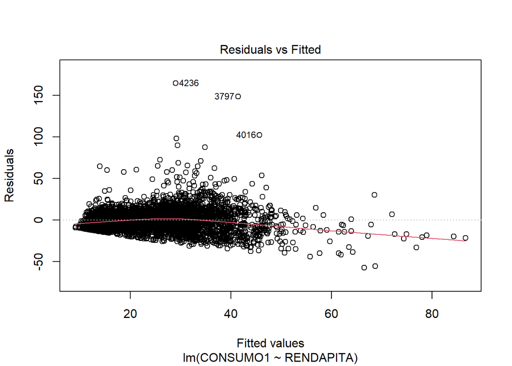

```r
plot(modelo1, which = 1)
```

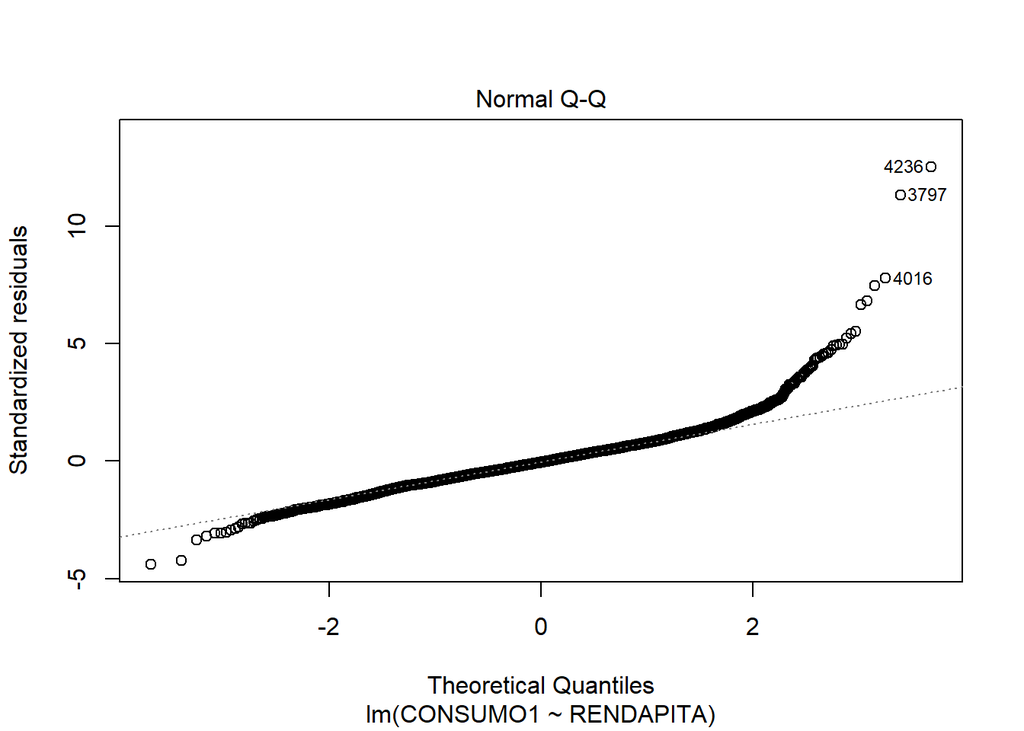

```r
plot(modelo1, which = 2)
```

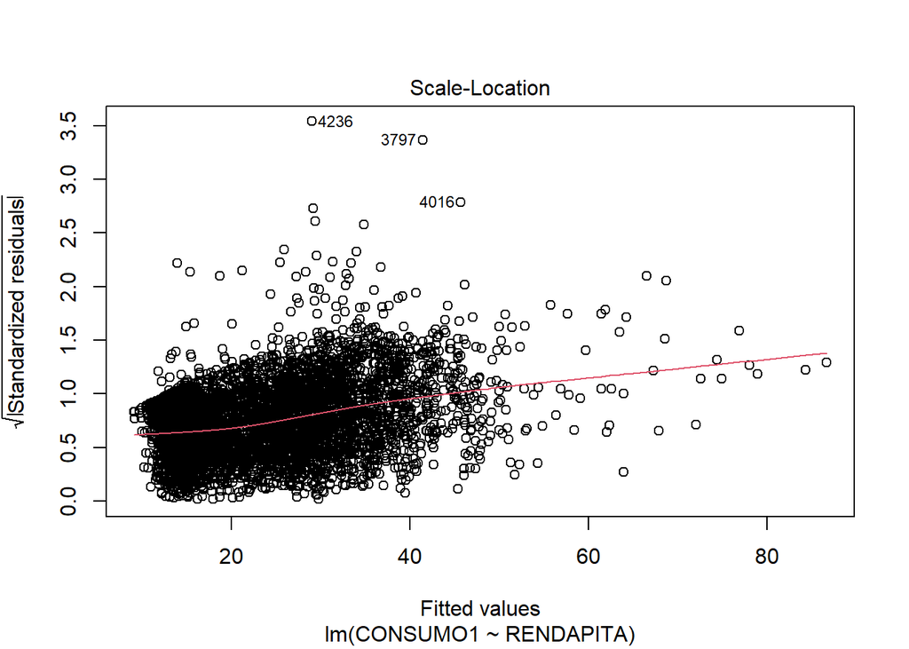

```r
plot(modelo1, which = 3)
```

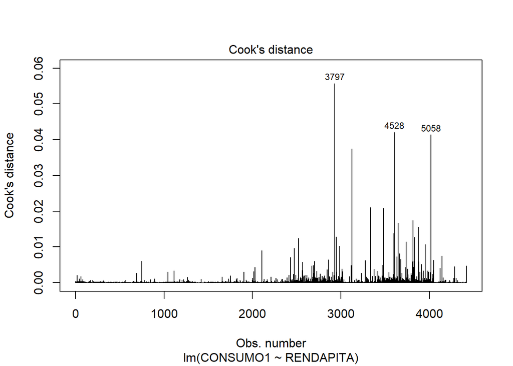

```r
plot(modelo1, which = 4)
```

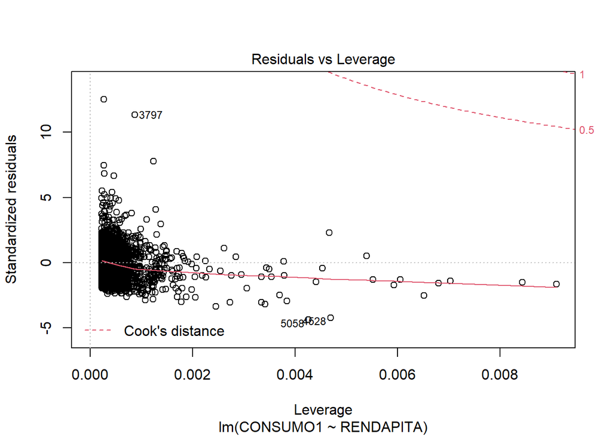

```r
plot(modelo1, which = 5)
```

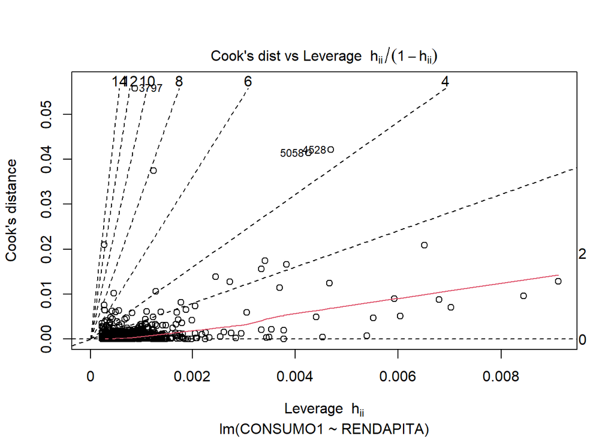

```r
plot(modelo1, which = 6)
```

### 2.3. Diagrama de dispersão com ajuste

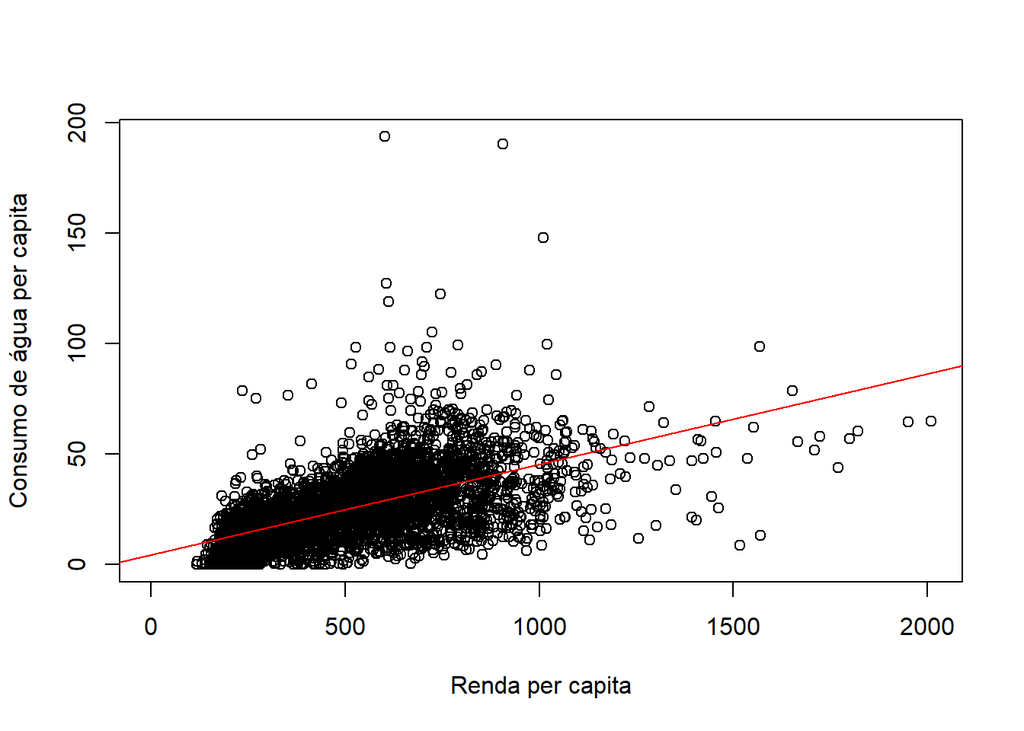

```r
plot(x = dados$RENDAPITA,
     y = dados$CONSUMO1,
     xlab = "Renda per capita",
     ylab = "Consumo de água per capita")
abline(modelo1, col = "red")
```

### 2.4. Salvando os resultados do modelo

regressão$fitted.values: calcula os valores preditos da variável resposta para cada elemento da amostra (faz uma previsão);

regressão$residuals: calcula o erro ou os resíduos (valor observado - valor predito) para cada ponto da amostra;

regressão$coefficients: obtém uma estimativa dos coeficientes da regressão.

# 3. Regressão linear múltipla

```r
modelo2 <- lm(formula = CONSUMO1 ~ RENDAPITA + PROPREDE, data = dados)
```

### 3.1. Estatísticas

### 3.2. Resumo do modelo

### 3.3. ANOVA

### 3.4. Parâmetros do modelo

### 3.5. Colinearidade

### 3.6. Diagnósticos por casos

### 3.7. Estatísticas salvas

### 3.8. Estatísticas de influência

### 3.9. Conferindo as hipóteses

### 3.10. Análise dos resíduos

### 4. (Extra) Comparando modelos

```r
library(performance)
```

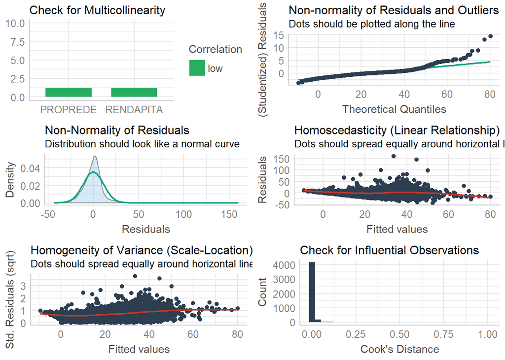

```r
check_model(modelo2)
```

```r
model_performance(modelo2)
```

```
## # Indices of model performance
##
##      AIC |      BIC |   R2 | R2_adjusted |  RMSE
## ------------------------------------------------
## 33983.66 | 34009.24 | 0.52 |        0.52 | 11.33
```

```r
compare_performance(modelo1, modelo2, rank = TRUE)
```

```
## # Comparison of Model Performance Indices
##
## Model   | Type |      AIC |      BIC |   R2 | R2_adjusted |  RMSE |        BF | Performance_Score
## -------------------------------------------------------------------------------------------------
## modelo2 |   lm | 33983.66 | 34009.24 | 0.52 |        0.52 | 11.33 | 1.33e+282 |           100.00%
## modelo1 |   lm | 35289.28 | 35308.46 | 0.36 |        0.36 | 13.13 |      1.00 |             0.00%
##
## Model modelo2 (of class lm) performed best with an overall performance score of 100.00%.
```

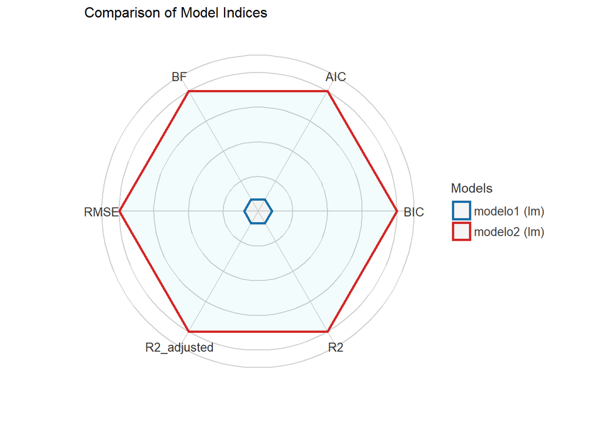

```r
plot(compare_performance(modelo1, modelo2, rank = TRUE))
```

# Tarefa 5

Utilizando os dados do seu trabalho de curso, conduza uma análise de regressão utilizando as técnicas apresentadas na aula prática.

Interprete seu modelo de regressão!!!